# Homework 1 (tm2925)

## HW 1: Problem 1

Create a data frame with a random sample of 10 with a uniform distribution, logical vector witih elements greater than 2, character vector and factor vector.

```r
hw1_q1_df = tibble(
  samp = runif(10, 0, 5),
  vec_logical = samp > 2,
  vec_character = c('a', 'b', 'c', 'd', 'e', 'f', 'g', 'h', 'i', 'j'),
  vec_factor = factor(c(vec_character))
)

##taking the mean of each variable
mean(hw1_q1_df$vec_logical)
```

```
## [1] 0.6
```

```r
mean(hw1_q1_df$vec_character)
```

```
## [1] NA
```

```r
mean(hw1_q1_df$vec_factor)
```

```
## [1] NA
```

**What works and what doesn’t? Why?** *The mean of a logical vector works, the mean of character or factor vectors do not work.*

Coercing vectors:

```r
as.numeric(hw1_q1_df$vec_logical)
as.numeric(hw1_q1_df$vec_character)
as.numeric(hw1_q1_df$vec_factor)
```

[output not shown]

**What happens?** *Character vectors are not able to be coerced into numeric vectors. This causes a warning message and NA.*

Converting variables:

```r
as.numeric(as.factor(hw1_q1_df$vec_character))
```

```
##  [1]  1  2  3  4  5  6  7  8  9 10
```

```r
as.numeric(as.character(hw1_q1_df$vec_factor))
```

```
## Warning: NAs introduced by coercion
```

```
##  [1] NA NA NA NA NA NA NA NA NA NA
```

**What happens?** *If character vectors are converted into factor vectors first, then they can be converted into numeric vectors. Similar to above, character vectors cannot be conerted into numeric vectors so the second function results in a warning message and NA.*

## HW 1: Problem 2

Create a data frame where x and y are a random sample of 1000 in a normal distribution, logical vector that indicates whether x + y > 0, logical vector coerced into a numeric vector, and a logical vector coerced into a factor vector.

```r
set.seed(124)
hw1_q2_df = tibble(
  x = rnorm (1000),
  y = rnorm (1000),
  vec_logical_xy = x + y > 0,
  vec_numeric_xy = as.numeric(vec_logical_xy),
  vec_factor_xy = as.factor(vec_numeric_xy),
)
```

**The size of the dataset is 1000 rows and 5 columns. The mean of x is -0.0653552. The median of x is -0.0805304. The proportion of cases for which the logical vector is TRUE is 0.472.**

## Creating scatterplots

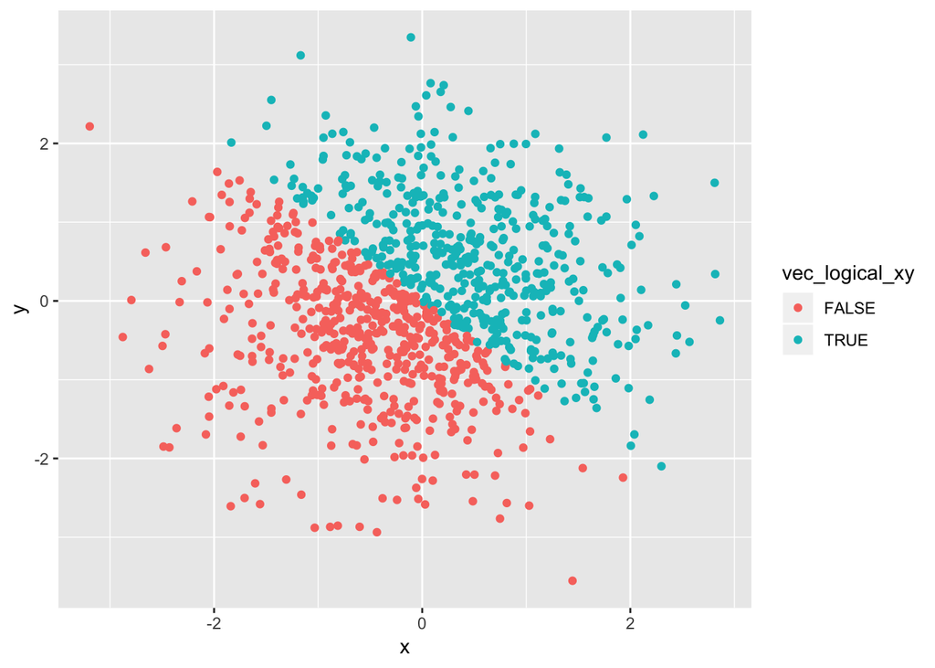

```r
ggplot(hw1_q2_df, aes(x, y, color = vec_logical_xy)) + geom_point()
```

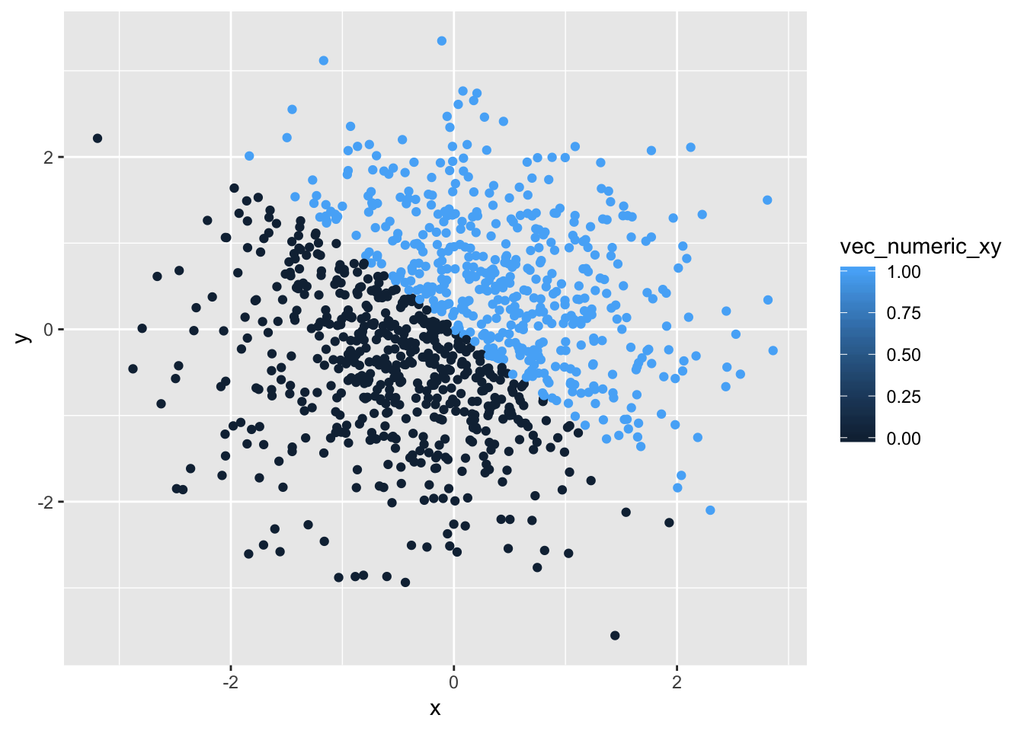

```r
ggplot(hw1_q2_df, aes(x, y, color = vec_numeric_xy)) + geom_point()
```

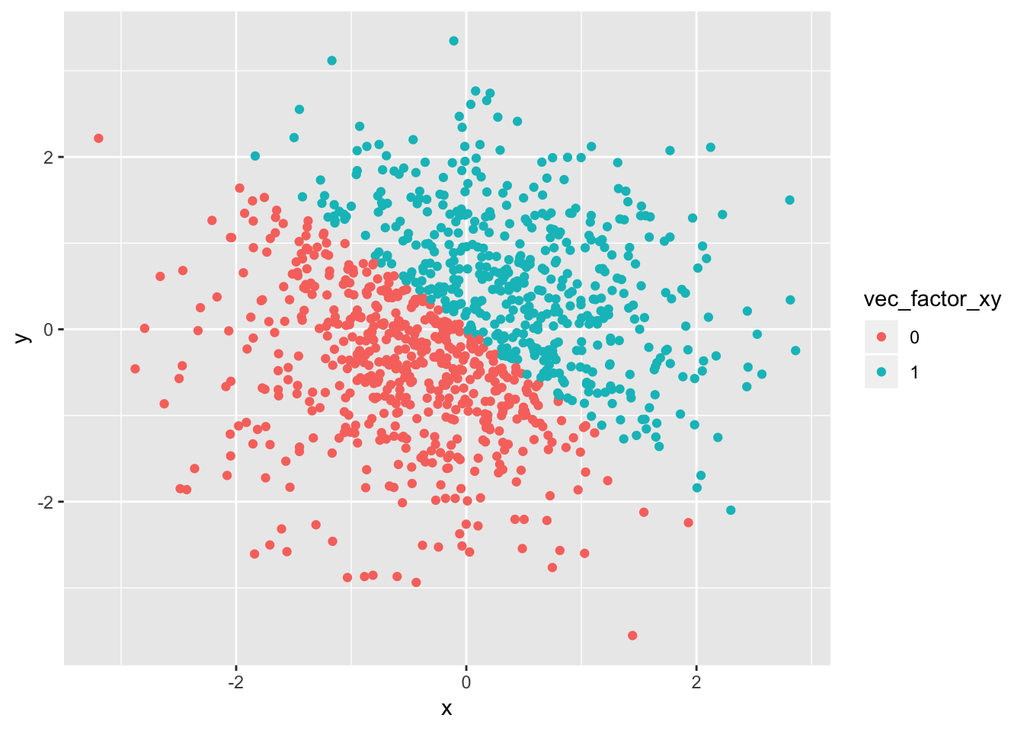

```r
ggplot(hw1_q2_df, aes(x, y, color = vec_factor_xy)) + geom_point()
```

```r
ggsave("HW_1_tm2925_scatter_plots.pdf", height = 4, width = 6)
```

**Comment on color scales.** *All scatterplots are similar in apperance. The logical and factor vector plots are exactly the same, but the legends differ (TRUE/FALSE) vs (0/1). The numeric vector displays a color scale, but since the vector only contains two options, only the colors at the two extremes (0/1) are displayed.*